# Thinking through a power analysis for a case series method for deaths and high heat days

Brooke Anderson

September 2, 2015

```r
library(dplyr)
library(lubridate)
library(ggplot2)
```

## Simple example

```r
sim_data <- data.frame(date = seq(from = as.Date("2000-01-01"),
                to = as.Date("2009-12-31"), by = 1)) %>%
        filter(months(date) %in% c("May", "June", "July",
                                  "August", "September"))
table(months(sim_data$date))
```

```
##
##    August      July      June       May September
##       310       310       300       310       300
```

```r
heat_days <- sample(sim_data$date, round(nrow(sim_data) * 0.02))
sim_data <- mutate(sim_data,
                   heat_day = date %in% heat_days,
                   year = format(date, "%Y"),
                   day_of_year = yday(date))
head(sim_data, 20)
```

```
##          date heat_day year day_of_year
## 1  2000-05-01    FALSE 2000         122
## 2  2000-05-02    FALSE 2000         123
## 3  2000-05-03    FALSE 2000         124
## 4  2000-05-04    FALSE 2000         125
## 5  2000-05-05    FALSE 2000         126
## 6  2000-05-06    FALSE 2000         127
## 7  2000-05-07    FALSE 2000         128
## 8  2000-05-08    FALSE 2000         129
## 9  2000-05-09    FALSE 2000         130
## 10 2000-05-10    FALSE 2000         131
## 11 2000-05-11    FALSE 2000         132
## 12 2000-05-12    FALSE 2000         133
## 13 2000-05-13    FALSE 2000         134
## 14 2000-05-14    FALSE 2000         135
## 15 2000-05-15    FALSE 2000         136
## 16 2000-05-16    FALSE 2000         137
## 17 2000-05-17    FALSE 2000         138
## 18 2000-05-18    FALSE 2000         139
## 19 2000-05-19    FALSE 2000         140
## 20 2000-05-20    FALSE 2000         141
```

The following plot shows the days that were randomly selected as heat days:

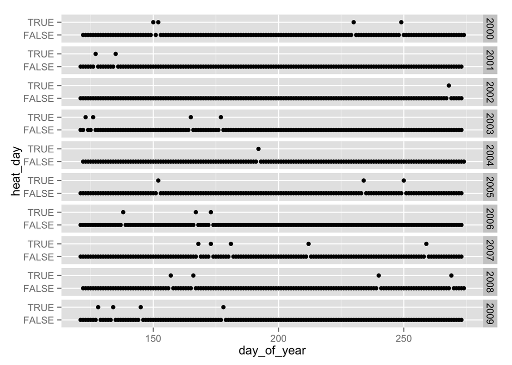

```r
ggplot(sim_data, aes(x = day_of_year, y = heat_day)) +
        geom_point() +
        facet_grid(year ~ . )
```

The next thing I’ll need to decide are:

1. What is the baseline rate of the outcome (e.g., cardiovascular death)
2. What is the effect size of a heat day (i.e., the relative incidence for heat days versus other days)

I’ll check out what I can see if I set the baseline rate of the outcome to be 50 per day and the relative incidence for a heat day to be 1.50 (i.e., a 50% increase):

```r
baseline_rate <- 50
RI <- 1.50
```

Now I’ll simulate the numbers of outcomes on each day. I’m assuming a Poisson distribution for the number of deaths:

```r
sim_data$outcome <- NA
risk_numbers <- table(sim_data$heat_day)
sim_data$outcome[sim_data$heat_day == FALSE] <- rpois(
                                                risk_numbers["FALSE"],
                                                       baseline_rate)
sim_data$outcome[sim_data$heat_day == TRUE] <- rpois(
                                                risk_numbers["TRUE"],
                                                baseline_rate * RI)
```

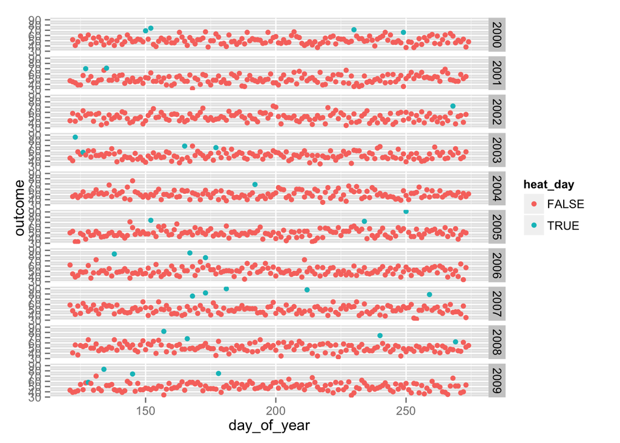

```r
ggplot(sim_data, aes(x = day_of_year, y = outcome, color = heat_day)) +
        geom_point() +
        facet_grid(year ~ .)
```

You can see from this that, with a relative incidence of 1.50 and all the other assumptions, you can clearly pick out an increase in incidence during risk days just by eye-balling the figure.

Now, I can run a GLM on this to see if I identify the effect:

```r
mod_1 <- glm(outcome ~ heat_day, data = sim_data,
             family = poisson(link = "log"))
summary(mod_1)$coef
```

```
##               Estimate  Std. Error   z value     Pr(>|z|)
## (Intercept)  3.9164163 0.003644687 1074.5550 0.000000e+00
## heat_dayTRUE 0.3954647 0.021114206   18.7298 2.830035e-78
```

```r
exp(summary(mod_1)$coef[2, 1])
```

```
## [1] 1.485074
```

```r
exp(confint(mod_1)[2, ])
```

```
##    2.5 %   97.5 %
## 1.424486 1.547407
```

This has generated a point estimate almost identical to the RI used in the model, and the confidence interval is surrounding the specified RI. The p-value for the heat days coefficient is 2.830034810^{-78}, well below 0.05.